# Linear Regression with JAX

In linear regression we assume that our data can be represented as

\begin{equation} y(\vec{x},t) = w_o + \sum_{i=1}^{M-1} w_i \phi_i(\vec{x}) \end{equation}

where $\phi(\vec{x})$ are the basis functions that can be gaussian, sigmoid, tanh.

If we suppose we have a dataset $\vec{x}=(x_1,x_2 ...x_n)$ representing $N$ observations and we assume that the observations are i.i.d (independent + identically distributed). The predicted output $y$ can be defined as a deterministic prediction + a gaussian noise $$ t = y(\vec{x},t) + N(0,\sigma^2) $$ where $\epsilon$ is gaussian noise. This implies for a specific $x_i$, the predicted output follows a gaussian distribution with mean $y$ and the gaussian noise std $\sigma^2$ $$ t \sim N(y, \sigma^2) $$ From this, the likelihood of the observed data t given the inputs, weights and gaussian noise variance is $$ p(t|\vec{x},\vec{w},\sigma^2) = N(y, \sigma^2) $$ and the joint PDF $$ p(t|\vec{x},\vec{w},\sigma^2) = \prod_i^{N_{\text{samples}}} N(y_i(x_i,w), \sigma^2) $$ The joint pdf has dimension $D=N_{\text{samples}}$ but the marginal PDF distribution for one specific $x_i$ maps to the gaussian

The joint pdf can be maximized by taking the log of the pdf $$ p(t|\vec{x},\vec{w},\sigma^2) = \prod_i^{N_{\text{samples}}} \ln{ \frac{1}{\sqrt{2 \pi \sigma^2}} \exp{\frac{-(t_i-y_i)}{2\sigma^2}} } $$ with some rearrangements $$ \ln p(t | \vec{x}, \vec{w}, \sigma^2) = -\frac{N_{\text{samples}}}{2} \ln(2\pi\sigma^2) - \frac{1}{2\sigma^2} \sum_{i=1}^{N_{\text{samples}}} (t_i - y_i(x_i, w))^2 $$ Maximizing the likelihood with respect to the gaussian noise $\sigma^2$, it possible to find the $\sigma$ that maximizies the likelihood MLE $$ \sigma_{\text{MLE}}^2 = \frac{1}{N_{\text{samples}}} \sum_i^{N_{\text{samples}}} (t_i-y_i)^2 $$ It is directly observed that to max the likelihood the second term needs to be minimized by the weights, which is the sum of the squared errors $$ \vec{w}_{\text{MLE}} = min \sum_i^{N_{\text{samples}}} (t_i-y_i(x_i, \vec{w}))^2 $$

Note that the optimal std for the added noise is related to the average square diff between predictions and true values. The closer the predictions the smaller the std and viceversa

### Jax implementation of MLE

We will implement a linear regression using MLE (maximum likelihood estimator)

```python
import jax
import jax.numpy as jnp
from sklearn.datasets import fetch_openml
import matplotlib.pyplot as plt
import seaborn as sns

# Load Boston Housing dataset from OpenML
boston = fetch_openml(name="boston", version=1, as_frame=True)
X = boston.data
y = boston.target
```

- **CRIM**: Per capita crime rate by town
- **ZN**: Proportion of residential land zoned for lots over 25,000 sq.ft.
- **INDUS**: Proportion of non-retail business acres per town
- **CHAS**: Charles River dummy variable (= 1 if tract bounds river; 0 otherwise)
- **NOX**: Nitric oxides concentration (parts per 10 million)
- **RM**: Average number of rooms per dwelling
- **AGE**: Proportion of owner-occupied units built prior to 1940
- **DIS**: Weighted distances to five Boston employment centres
- **RAD**: Index of accessibility to radial highways
- **TAX**: Full-value property-tax rate per $10,000
- **PTRATIO**: Pupil-teacher ratio by town
- **B**: (1000(B_k - 0.63)^2) where (B_k) is the proportion of blacks by town
- **LSTAT**: % lower status of the population

```python
print(X.describe())
print("\nMissing Values:")
print(X.isnull().sum())
```

```
             CRIM          ZN       INDUS         NOX          RM         AGE  \
count  506.000000  506.000000  506.000000  506.000000  506.000000  506.000000
mean     3.613524   11.363636   11.136779    0.554695    6.284634   68.574901
std      8.601545   23.322453    6.860353    0.115878    0.702617   28.148861
min      0.006320    0.000000    0.460000    0.385000    3.561000    2.900000
25%      0.082045    0.000000    5.190000    0.449000    5.885500   45.025000
50%      0.256510    0.000000    9.690000    0.538000    6.208500   77.500000
75%      3.677083   12.500000   18.100000    0.624000    6.623500   94.075000
max     88.976200  100.000000   27.740000    0.871000    8.780000  100.000000

              DIS         TAX     PTRATIO           B       LSTAT
count  506.000000  506.000000  506.000000  506.000000  506.000000
mean     3.795043  408.237154   18.455534  356.674032   12.653063
std      2.105710  168.537116    2.164946   91.294864    7.141062
min      1.129600  187.000000   12.600000    0.320000    1.730000
25%      2.100175  279.000000   17.400000  375.377500    6.950000
50%      3.207450  330.000000   19.050000  391.440000   11.360000
75%      5.188425  666.000000   20.200000  396.225000   16.955000
max     12.126500  711.000000   22.000000  396.900000   37.970000

Missing Values:
CRIM       0
ZN         0
INDUS      0
CHAS       0
NOX        0
RM         0
AGE        0
DIS        0
RAD        0
TAX        0
PTRATIO    0
B          0
LSTAT      0
dtype: int64
```

The covariance is the crossproduct between deviations from the mean of two different variables and the correlation matrix (following Pearsons approach) normalizes it by the two variances $$ \frac{\sum_i^N (x_i-\overline{x})(y_i-\overline{y})}{\sigma_x^2 \sigma_y^2} $$ Pearsons can go from -1 to 1, telling us high correlation means more strong correlationship. Negative means when one increases the other decreases from the sign of the covariance, and viceversa.

I have used spearman to be less sensitive to outliers. Spearman uses the same formula but computes ranks based on the distance to the mean an computes the Correlations with the ranks

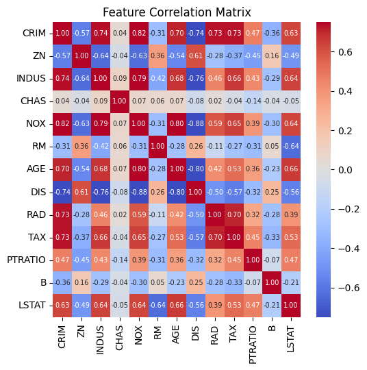

```python
plt.figure(figsize=(5.5, 5.5))
#compute correlation matrix using spearman
#reduce fontsize of the annotations
sns.heatmap(X.corr(method='spearman'), annot=True, cmap="coolwarm", fmt='.2f', vmin=-0.75, vmax=0.75, annot_kws={"fontsize": 7})
plt.title('Feature Correlation Matrix')
plt.tight_layout()
plt.show()
```

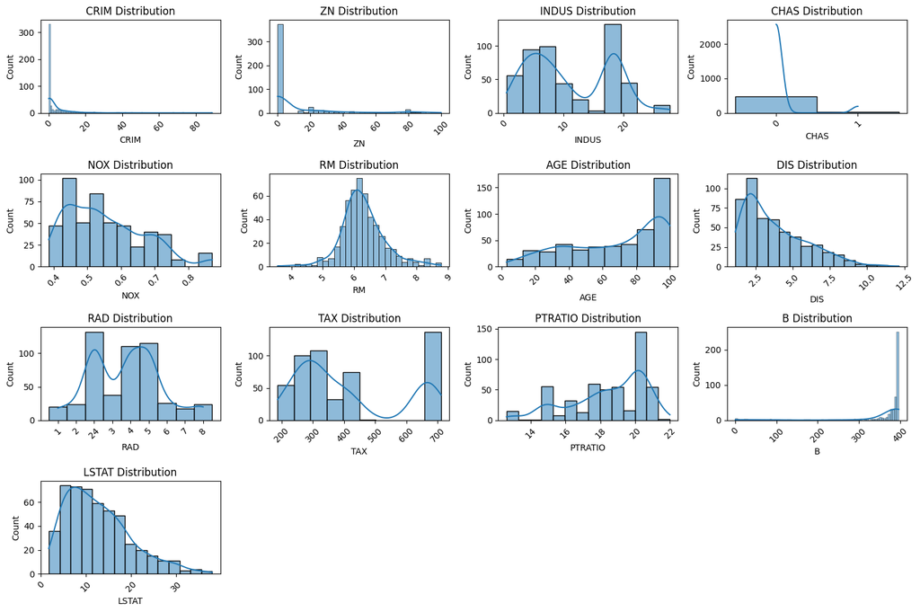

```python
plt.figure(figsize=(15, 10))
for i, column in enumerate(X.columns, 1):
    plt.subplot(4, 4, i)
    sns.histplot(X[column], kde=True)
    plt.title(f'{column} Distribution')
    plt.xticks(rotation=45)
plt.tight_layout()
plt.show()
```

The output is:

- **MEDV**: % Median value of owner-occupied homes in thousands of dollars

Let's look at correlation + feature insights

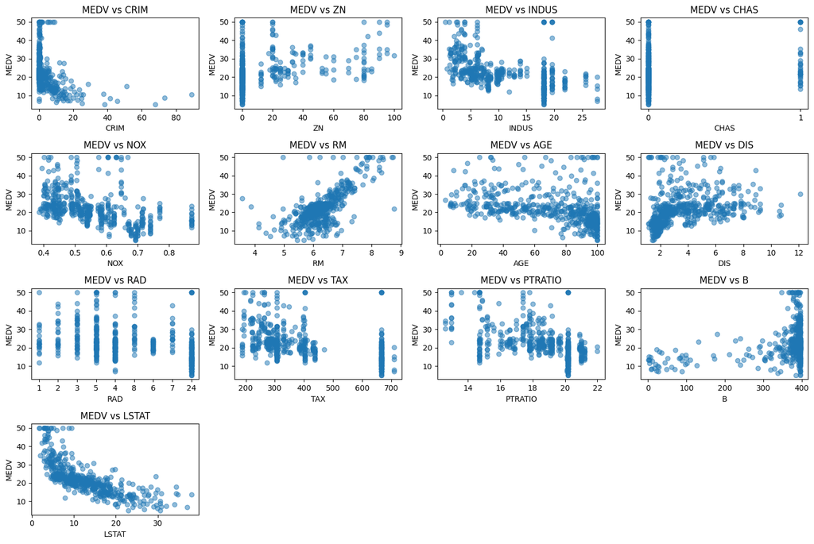

```python
plt.figure(figsize=(15, 10))
for i, column in enumerate(X.columns, 1):
    plt.subplot(4, 4, i)
    plt.scatter(X[column], y, alpha=0.5)
    plt.xlabel(column)
    plt.ylabel('MEDV')
    plt.title(f'MEDV vs {column}')
plt.tight_layout()
plt.show()
```

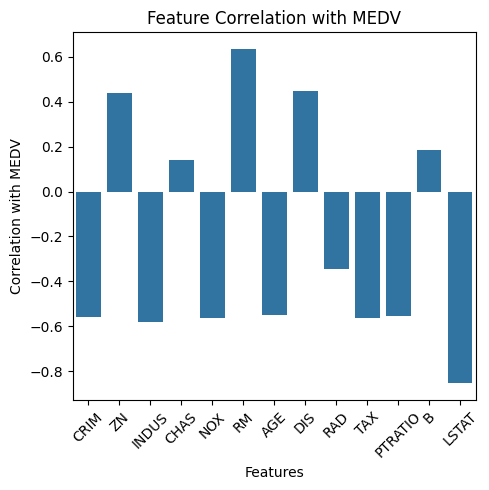

```python
plt.figure(figsize=(8, 8))
import pandas as pd
pandas_y = pd.Series(y)
X_corr_y = X.corrwith(pandas_y,method='spearman')
X_corr_y.sort_values(ascending=False)
#plot X_corr_y
plt.figure(figsize=(5, 5))
sns.barplot(x=X_corr_y.index, y=X_corr_y.values)
plt.xticks(rotation=45)
plt.xlabel('Features')
plt.ylabel('Correlation with MEDV')
plt.title('Feature Correlation with MEDV')
plt.tight_layout()
plt.show()
```

We will now use JAX to basically solve a linear regression problem using MLE estimator. We will use sklearn to preprocess the type of variables and then feed it into the JAX framework

```python
import jax
import jax.numpy as jnp
import numpy as np
from sklearn.preprocessing import StandardScaler, MinMaxScaler, OneHotEncoder
from sklearn.compose import ColumnTransformer
from sklearn.model_selection import train_test_split

categorical_features = ['CHAS']
ordinal_features = ['RAD']
numerical_features = [x for x in X.columns if x not in categorical_features and x not in ordinal_features]

preprocessor = ColumnTransformer(
    transformers=[
        ('num', StandardScaler(), numerical_features),
        ('cat', OneHotEncoder(), categorical_features),
        ('ord', MinMaxScaler(), ordinal_features)
    ])

X_transformed = preprocessor.fit_transform(X)
variables = preprocessor.get_feature_names_out()

X_numpy = np.array(X_transformed, dtype=np.float32)
y_numpy = np.array(y.to_numpy(), dtype=np.float32)

y_scaler = StandardScaler()
y_numpy_scaler_output = y_scaler.fit_transform(pd.DataFrame(y_numpy))
y_numpy_scaler_output = y_numpy_scaler_output.reshape(-1,1)
y_numpy_scaler_output = y_numpy_scaler_output.reshape(-1)

X_train, X_val, y_train, y_val = train_test_split(X_numpy, y_numpy_scaler_output, test_size=0.15, random_state=42)

def compute_jax_arrays(X,y):
    #add bias column to X
    X_jax = jnp.array(X)
    y_jax = jnp.array(y)
    return X_jax, y_jax

X_train_jax, y_train_jax = compute_jax_arrays(X_train, y_train)
X_val_jax, y_val_jax = compute_jax_arrays(X_val, y_val)

print("Jax arrays shapes")
print("Train:", X_train_jax.shape, y_train_jax.shape)
print("Validation:", X_val_jax.shape, y_val_jax.shape)
```

```
Jax arrays shapes
Train: (430, 14) (430,)
Validation: (76, 14) (76,)
```

We now implement the function we want to optimize (loss) $$ - \ln p(t | \vec{x}, \vec{w}, \sigma^2) = \frac{N_{\text{samples}}}{2} \ln(2\pi\sigma^2) + \frac{1}{2\sigma^2} \sum_{i=1}^{N_{\text{samples}}} (t_i - y_i(x_i, w))^2 $$

```python
from jax import grad, jit

@jit
def negative_log_likelihood(params, X, y):
    w = params['w']
    b = params['b']
    sigma = params['sigma']
    N_samples = X.shape[0]
    residuals = y - (jnp.dot(X, w) + b)
    likelihood = 0.5*(N_samples * jnp.log(2 * jnp.pi * sigma**2) + jnp.sum(residuals ** 2) / sigma**2)
    return likelihood

#automatically derives the function with respect to the first argument
grad_negative_log_likelihood = grad(negative_log_likelihood)
```

JAX creates some kind of graph that links very basic functions, the grad is computed using backward pass reversing the order on the graph while applying the chain rule of each derivative. I have implemented an Adam optimizer using the first and second moment of the gradients to boost optimization

```python
import jax.random as random
from tqdm import tqdm

def train(params, loss, X_train, y_train, X_val, y_val, learning_rate, epochs, n_batches):

    momentum = jax.tree_map(jnp.zeros_like, params)
    second_momentum = jax.tree_map(jnp.zeros_like, params)

    beta = 0.9
    beta2 = 0.999
    time_step = 1
    #split in batches
    X_train_batches = jnp.array_split(X_train, n_batches)
    y_train_batches = jnp.array_split(y_train, n_batches)
    p_bar = tqdm(range(epochs))
    history = {"train_loss":[], "val_loss":[], "train_mse":[], "val_mse":[]}
    grad_loss = grad(loss)

    for i in p_bar:
        val_loss = 0
        train_loss = 0

        train_pred = jnp.dot(X_train, params['w']) + params['b']
        val_pred = jnp.dot(X_val, params['w']) + params['b']

        train_mse = jnp.mean((y_train - train_pred)**2)
        val_mse = jnp.mean((y_val - val_pred)**2)

        for batch in range(n_batches):
            #compute predictions (forward pass)
            X_batch = X_train_batches[batch]
            y_batch = y_train_batches[batch]

            #loss
            train_loss += loss(params, X_batch, y_batch)

            #backward pass
            grads = grad_loss(params, X_batch, y_batch)

            momentum = jax.tree_map(lambda past_g, g: past_g * beta + g * (1-beta), momentum, grads)
            second_momentum = jax.tree_map(lambda past_g, g: past_g * beta2 + (g*g) * (1-beta2), second_momentum, grads)

            corrected_momentum = jax.tree_map(lambda g: g/jnp.sqrt(1-beta**time_step), momentum)
            corrected_second_momentum = jax.tree_map(lambda g: g/jnp.sqrt(1-beta2**time_step), second_momentum)

            params = jax.tree_map(lambda p, g, s: p - learning_rate * g / (jnp.sqrt(s) + 1e-8), params, corrected_momentum, corrected_second_momentum)

            val_loss += negative_log_likelihood(params, X_val, y_val)
            time_step += 1

        p_bar.set_postfix({"Training Loss": train_loss/n_batches, "Validation Loss": val_loss/n_batches,"Training MSE": train_mse,"Validation MSE": val_mse})
        p_bar.set_description(f"Epoch {i}")
        history["train_loss"].append(train_loss/n_batches)
        history["val_loss"].append(val_loss/n_batches)
        history["train_mse"].append(train_mse/n_batches)
        history["val_mse"].append(val_mse/n_batches)

    return params, history

w = jnp.zeros(X_train.shape[1])
b = jnp.array(0.0)
sigma = jnp.array(0.5)
params = {
    'w': w,
    'b': b,
    'sigma': sigma
}

optimized_params , history= train(params,negative_log_likelihood,X_train_jax, y_train_jax, X_val_jax, y_val_jax, learning_rate=1e-3, epochs=500, n_batches=24)
```

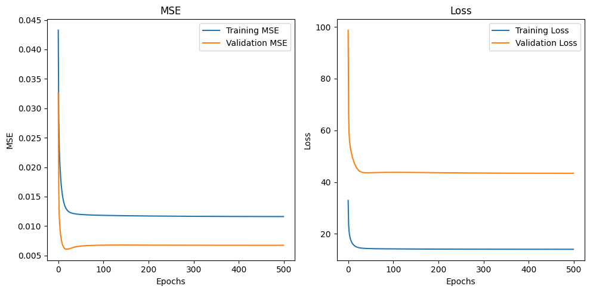

```python
fig, axes = plt.subplots(1,2,figsize=(10,5))
axes[0].plot(history["train_mse"],label="Training MSE")
axes[0].plot(history["val_mse"],label="Validation MSE")
axes[0].legend()
axes[0].set_xlabel('Epochs')
axes[0].set_ylabel('MSE')
axes[0].set_title('MSE')
axes[1].plot(history["train_loss"],label="Training Loss")
axes[1].plot(history["val_loss"],label="Validation Loss")
axes[1].legend()
axes[1].set_xlabel('Epochs')
axes[1].set_ylabel('Loss')
axes[1].set_title('Loss')
plt.tight_layout()
plt.show()
```

### Closed-form solution

From the log likelihood is possible to obtain a solution directly from the derivative $\frac{\partial L}{\partial w}$. Note that assuming Gaussian noise is the same as solving the Least Squares problem

$$ \frac{\partial L}{\partial w} = - \frac{1}{\sigma^2} \sum_{i=1}^{N_{\text{samples}}} 2 (t_i - y_i(x_i, w)) \frac{\partial y_i}{\partial w} = 0 $$

$$ \frac{\partial L}{\partial w} = \sum_{i=1}^{N_{\text{samples}}} 2 (t_i - x_i W)) x_i = 0 $$ Can be rearranged as

$$ X^T (t - X W) = 0 \\ X^T X W = X^T t \\ $$ where W contains already the bias and X a column of ones. Can be solved using $Ax=b$ inverting $X^T X$

```python
def closed_form_solution(X,y):
    XTX = jnp.matmul(X.T,X)
    XTt = jnp.matmul(X.T,y)
    W = jnp.matmul(jnp.linalg.inv(XTX),XTt)
    return W
```

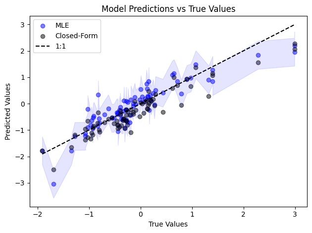

```python
import jax.random as random
#can we plot one y-x axis plot with the model predictions and the true values?

def plot_predictions_comparison(y_true, X_val, optimized_params, label, closed_form=True,color="blue"):
    # MLE predictions
    y_mle = jnp.dot(X_val, optimized_params['w']) + optimized_params['b']
    plt.scatter(y_true, y_mle, alpha=0.5, label=label,color=color)

    # Closed-form solution if requested
    if closed_form:
        X_closed_form = np.concatenate([np.ones((X_val.shape[0], 1)), X_val], axis=1)
        W = closed_form_solution(X_closed_form, y_true)
        y_closed_form = jnp.dot(X_closed_form, W)
        plt.scatter(y_true, y_closed_form, alpha=0.5, label="Closed-Form",color="black")

    # Sort for confidence interval
    sort_index = jnp.argsort(y_true)
    y_true_sorted = y_true[sort_index]
    X_val_sorted = X_val[sort_index]

    # Confidence interval
    y_pred_sorted = jnp.dot(X_val_sorted, optimized_params['w']) + optimized_params['b']
    sigma = optimized_params["sigma"]
    plt.fill_between(y_true_sorted,
                    y_pred_sorted - sigma,
                    y_pred_sorted + sigma,
                    alpha=0.1, color=color)

    plt.xlabel('True Values')
    plt.ylabel('Predicted Values')
    plt.title('Model Predictions vs True Values')
    plt.tight_layout()


# Example usage
plot_predictions_comparison(y_val, X_val,optimized_params,"MLE")
plt.plot(np.linspace(y_val.min(), y_val.max(), 100),
             np.linspace(y_val.min(), y_val.max(), 100),
             color="black", linestyle="--", label="1:1")
plt.legend()
plt.show()
```

## Bayesian View

If we consider again the standard linear regression model, the target can be described with the prediction plus random noise:

$$ \mathbf{t} = \mathbf{X} \mathbf{w} + \boldsymbol{\epsilon}, \quad \boldsymbol{\epsilon} \sim \mathcal{N}(\mathbf{0}, \sigma^2 \mathbf{I}), $$ Under the Gaussian noise assumption, the likelihood of the data given (\mathbf{w}) is determined by the following formula:

$$ p(t|\vec{x},\vec{w},\sigma^2) = \sum_i^{N_{\text{samples}}} \ln{ \frac{1}{\sqrt{2 \pi \sigma^2}} \exp{\frac{-(t_i-\mathbf{X} \mathbf{w})}{2\sigma^2}} } $$

### Prior

From the definition of joint probability, we have: $$ p(D \mid w)\, p(w) \;=\; p(D, w) \;=\; p(w \mid D)\, p(D). $$

$\textbf{Posterior:}$ $p(w \mid D)$ - Given a dataset $D$, how likely is each weight?

$\textbf{Prior:}$ $p(w)$ - The prior represents the probability distribution of the weights without any data. This is chosen based on the domain knowledge or mathematical convenience (One example could be Gaussian centered at 0)

$\textbf{Likelihood:}$ $p(D \mid w)$ - How likely is the model to observe dataset (D) given a particular choice of weights (w)? I imagine this as a pdf where the x-axis is the datapoint $x_i$. Because a dataset contains many points the likelihood is a product of these pdf's (joint probability)

From the bayesian equation then, we can maximize the posterior by including the prior to the likelihood. Considering the following prior, where each weight is independent following the same normal distribution $$ p(\mathbf{w}) \;=\; \mathcal{N}(\mathbf{0}, \tau^2) \;\;\;\Longrightarrow\;\;\; p(\mathbf{w}) \;\;\propto\;\; \exp\!\Bigl(-\tfrac{1}{2\tau^2}\|\mathbf{w}\|^2\Bigr). $$

Taking the negative log of the prior (up to additive constants) gives:

$$ p(t|\vec{x},\vec{w},\sigma^2,\tau^2) = \prod_i^{N_{\text{samples}}} { \frac{1}{\sqrt{2 \pi \sigma^2}} \exp{\frac{-(t_i-\mathbf{X} \mathbf{w})}{2\sigma^2}} } \prod_j^{D} { \frac{1}{\sqrt{2 \pi \tau^2}} \exp{\frac{-(w_j)}{2\tau^2}} } $$

Taking the negative log $$ -\log p(t|\vec{x},\vec{w},\sigma^2,\tau^2) = \frac{N_{\text{samples}}}{2} {2 \pi \sigma^2} + \frac{D}{2} {{2 \pi \tau^2}} \sum_i^{N_{\text{samples}}} \frac{(t_i-\mathbf{X} \mathbf{w})^2}{2\sigma^2} + \sum_j^{D} \frac{(w_j)^2}{2\tau^2} $$

```python
@jit
def posterior_loss(params, X, y):
    w = params['w']
    b = params['b']
    tau = params['tau']
    features = X.shape[1]
    posterior_loss = jnp.sum(w**2)/(2*tau**2) + (features/2)*jnp.log(2*jnp.pi*tau**2)
    total_loss = negative_log_likelihood(params, X, y) + posterior_loss
    return total_loss

@jit
def negative_log_likelihood(params, X, y):
    w = params['w']
    b = params['b']
    sigma = params['sigma']
    N_samples = X.shape[0]
    residuals = y - (jnp.dot(X, w) + b)
    likelihood = 0.5*(N_samples * jnp.log(2 * jnp.pi * sigma**2) + jnp.sum(residuals ** 2) / sigma**2)
    return likelihood
```

```python
w = jnp.zeros(X_train.shape[1])
b = jnp.array(0.0)
sigma = jnp.array(0.5)
tau = jnp.array(1.)

ridge_params = {
    'w': w,
    'b': b,
    'sigma': sigma,
    'tau': tau
}

ridge_optimized_params , ridge_history= train(ridge_params,posterior_loss,X_train_jax, y_train_jax, X_val_jax, y_val_jax, learning_rate=2e-5, epochs=1000, n_batches=24)
```

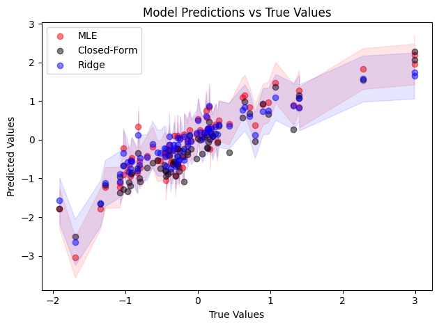

```python
plot_predictions_comparison(y_val, X_val, optimized_params,closed_form=True,label="MLE", color="red")
plot_predictions_comparison(y_val, X_val, ridge_optimized_params,label="Ridge",closed_form=False,color="blue")

plt.legend()
plt.show()
```

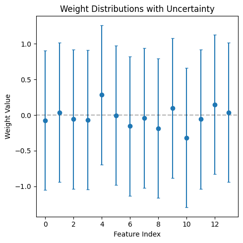

```python
plt.figure(figsize=(5, 5))
# Get weights and their uncertainties
weights = ridge_optimized_params['w']
weight_std = ridge_optimized_params['tau']
# Plot weights with error bars
plt.errorbar(range(len(weights)), weights,
            yerr=1.96 * weight_std,
            fmt='o', capsize=2)
plt.axhline(y=0, color='k', linestyle='--', alpha=0.3)
plt.xlabel('Feature Index')
plt.ylabel('Weight Value')
plt.title('Weight Distributions with Uncertainty')
plt.tight_layout()
plt.show()
```

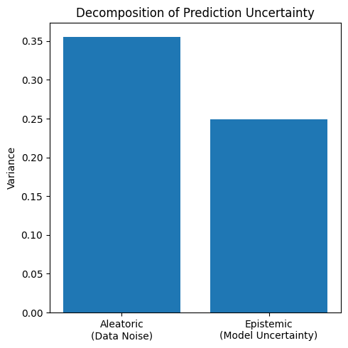

```python
plt.figure(figsize=(5, 5))

# Create bar plot showing both sources of uncertainty
uncertainties = [ridge_optimized_params['sigma']**2, ridge_optimized_params['tau']**2]
labels = ['Aleatoric\n(Data Noise)', 'Epistemic\n(Model Uncertainty)']

plt.bar(labels, uncertainties)
plt.ylabel('Variance')
plt.title('Decomposition of Prediction Uncertainty')
plt.tight_layout()
plt.show()
```

Another model that is also known in linear regression is "Lasso", which assumes a Laplacian pdf for the prior

$$ p(w) = \prod_j^{D} \frac{\lambda}{2} \exp{{- \lambda |w_j|}} $$

$$ -ln(p(w)) = - D \ln (\frac{\lambda}{2}) + \sum_j^{D} {\lambda |w_j|} $$

The prior tends to reduce large weights due to the exponential function and pulls small weights towards 0. This is a form of regularization that can be used to prevent overfitting. The larger the $\lambda$ the less weight spread

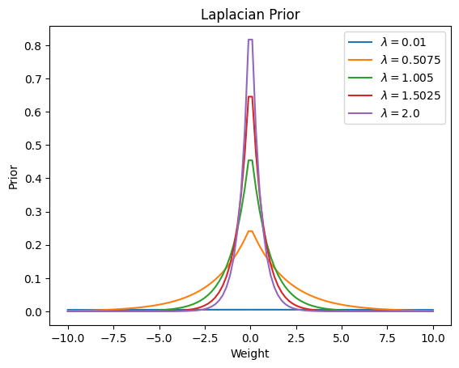

```python
lambas = np.linspace(0.01,2,5)
lambdas = np.round(lambas,2)
w = np.linspace(-10,10,100)
for lambda_value in lambas:
    plt.plot(w,lambda_value/2*np.exp(-lambda_value*abs(w)),label=f"$\lambda={lambda_value}$")
plt.xlabel("Weight")
plt.ylabel("Prior")
plt.title("Laplacian Prior")
plt.legend()
plt.show()
```

```python
def lasso_loss(params, X, y):
    w = params['w']
    b = params['b']
    lambda_value = params['lambda']
    features = X.shape[1]
    lasso_loss = lambda_value * jnp.sum(jnp.abs(w)) + features * jnp.log(2/lambda_value)
    total_loss = negative_log_likelihood(params, X, y) + lasso_loss
    return total_loss
```

```python
w = jnp.zeros(X_train.shape[1])
b = jnp.array(0.0)
sigma = jnp.array(0.5)
lambda_value = jnp.array(1.)

lasso_params = {
    'w': w,
    'b': b,
    'sigma': sigma,
    'lambda': lambda_value
}

lasso_optimized_params , lasso_history= train(lasso_params,lasso_loss,X_train_jax, y_train_jax, X_val_jax, y_val_jax, learning_rate=3e-5, epochs=1000, n_batches=24)
```

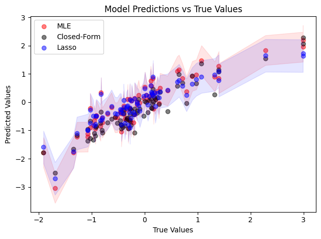

```python
plot_predictions_comparison(y_val, X_val, optimized_params,closed_form=True,label="MLE", color="red")
plot_predictions_comparison(y_val, X_val, lasso_optimized_params,label="Lasso",closed_form=False,color="blue")

plt.legend()
plt.show()
```

This prior basically reduces large weights due to the exponential function and maximizies small weights

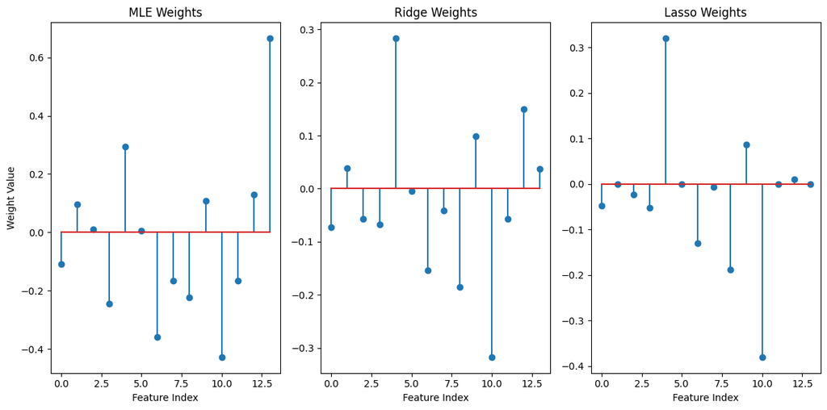

```python
plt.figure(figsize=(12, 6))

# Plot weights for each model
plt.subplot(1, 3, 1)
plt.stem(optimized_params['w'])
plt.title('MLE Weights')
plt.xlabel('Feature Index')
plt.ylabel('Weight Value')

plt.subplot(1, 3, 2)
plt.stem(ridge_optimized_params['w'])
plt.title('Ridge Weights')
plt.xlabel('Feature Index')

plt.subplot(1, 3, 3)
plt.stem(lasso_optimized_params['w'])
plt.title('Lasso Weights')
plt.xlabel('Feature Index')

plt.tight_layout()
plt.show()
```

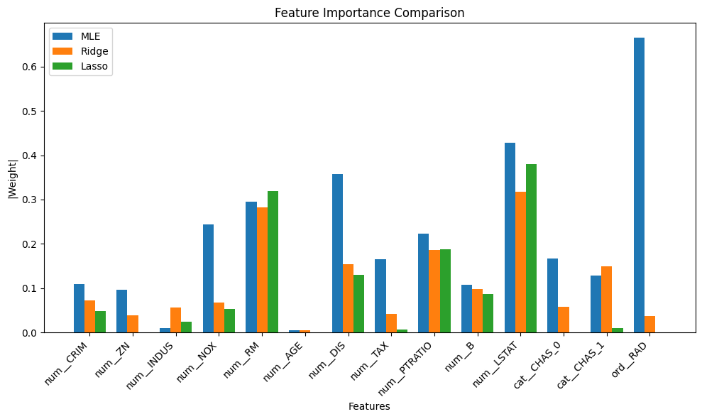

```python
plt.figure(figsize=(10, 6))

x = np.arange(len(variables))
width = 0.25

plt.bar(x - width, np.abs(optimized_params['w']), width, label='MLE')
plt.bar(x, np.abs(ridge_optimized_params['w']), width, label='Ridge')
plt.bar(x + width, np.abs(lasso_optimized_params['w']), width, label='Lasso')

plt.xlabel('Features')
plt.ylabel('|Weight|')
plt.title('Feature Importance Comparison')
plt.xticks(x, variables, rotation=45, ha='right')
plt.legend()
plt.tight_layout()
plt.show()
```

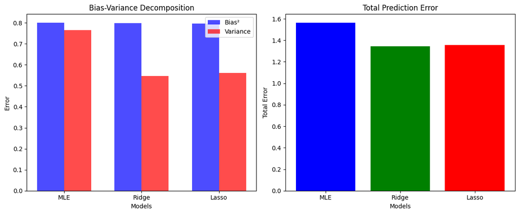

```
Numerical Results:
--------------------------------------------------

MLE:
Bias²: 0.8013
Variance: 0.7641
Total Error: 1.5654

Ridge:
Bias²: 0.7986
Variance: 0.5461
Total Error: 1.3446

Lasso:
Bias²: 0.7968
Variance: 0.5606
Total Error: 1.3574
```

```python
import jax.random as random

def compute_bias_variance(model_params, X, y_true, n_bootstrap=100):
    """
    Compute bias and variance using bootstrap sampling
    """
    predictions = []
    n_samples = X.shape[0]

    # Generate bootstrap predictions
    key = random.PRNGKey(0)
    for i in range(n_bootstrap):
        # Bootstrap sampling
        key, subkey = random.split(key)
        indices = random.choice(subkey, n_samples, shape=(n_samples,), replace=True)
        X_boot = X[indices]

        # Make predictions
        y_pred = jnp.dot(X_boot, model_params['w']) + model_params['b']
        predictions.append(y_pred)

    # Convert predictions to array
    predictions = jnp.array(predictions)

    # Compute mean prediction
    mean_pred = jnp.mean(predictions, axis=0)

    # Compute bias
    bias = jnp.mean((mean_pred - y_true) ** 2)

    # Compute variance
    variance = jnp.mean(jnp.var(predictions, axis=0))

    # Compute total error
    total_error = bias + variance

    return bias, variance, total_error

# Compute metrics for each model
models = {
    'MLE': optimized_params,
    'Ridge': ridge_optimized_params,
    'Lasso': lasso_optimized_params
}

results = {}
for name, params in models.items():
    bias, variance, total_error = compute_bias_variance(params, X_val_jax, y_val_jax)
    results[name] = {
        'bias': float(bias),
        'variance': float(variance),
        'total_error': float(total_error)
    }

# Plotting
plt.figure(figsize=(12, 5))

# Plot 1: Bias-Variance Components
plt.subplot(1, 2, 1)
x = np.arange(len(results))
width = 0.35

bias_values = [results[model]['bias'] for model in results]
variance_values = [results[model]['variance'] for model in results]

plt.bar(x - width/2, bias_values, width, label='Bias²', color='blue', alpha=0.7)
plt.bar(x + width/2, variance_values, width, label='Variance', color='red', alpha=0.7)

plt.xlabel('Models')
plt.ylabel('Error')
plt.title('Bias-Variance Decomposition')
plt.xticks(x, results.keys())
plt.legend()

# Plot 2: Total Error
plt.subplot(1, 2, 2)
total_errors = [results[model]['total_error'] for model in results]
plt.bar(results.keys(), total_errors, color=['blue', 'green', 'red'])
plt.xlabel('Models')
plt.ylabel('Total Error')
plt.title('Total Prediction Error')

plt.tight_layout()
plt.show()

# Print numerical results
print("\nNumerical Results:")
print("-" * 50)
for model, metrics in results.items():
    print(f"\n{model}:")
    print(f"Bias²: {metrics['bias']:.4f}")
    print(f"Variance: {metrics['variance']:.4f}")
    print(f"Total Error: {metrics['total_error']:.4f}")
```